# eMOLT Weekly Update

*eMOLT Weekly Update 2023-02-10*

### Weekly Recap

Clayton Philbrook, a longterm eMOLT participant out of Matinicus Island, Maine, mailed in his Minilog probe a few days ago with data documenting 2022 being warm but not as warm as 2021 as seen in the figure below.

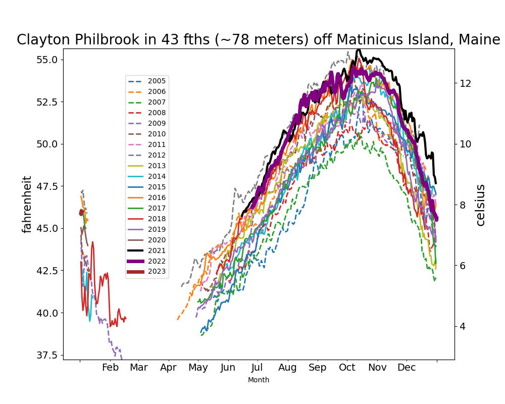

*Figure 1 – Temperatures from Clayton’s site*

In his recent tour of local used book stores, JiM came across a vintage publication from 1882 entitled “The Fishermen’s Own Book” where, among many other interesting sections, there was an account of the US Fish Commission’s “Summer Headquarters in Gloucester” under the direction of Spencer Baird in 1878. See photo below.

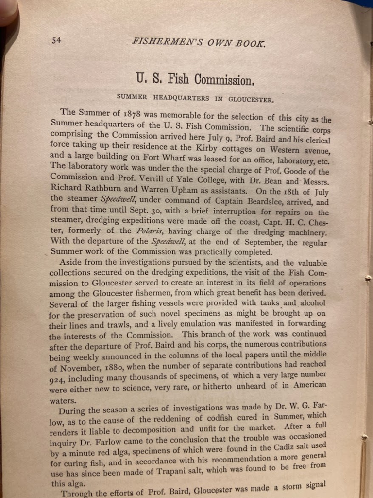

.

*Figure 2 – A snapshot from “The Fishermen’s Own Book”*

It is interesting to note that way back then, they had the idea to lease an office/laboratory in a large building on the wharf and that this “served to create an interest in its field of operations among the Gloucester fishermen”. Isn’t this what we should do? Set up operations at all the major fishing harbors in the Northeast? JiM suggest finding abandoned/unused vessels and turning them into offices/meeting spaces where we can all collaborate.

George and Huanxin went to the Lowell Instruments workshop on Wednesday to work on unifying our software and hardware platforms. Nick and Joaquim are going to test their software on an eMOLT deckbox and are exploring ways to add satellite communications to the Lowell deck data hubs.

Last Saturday, George went up to Portland, Maine for a meeting hosted by the Maine Lobster Institute. MLI has been funded by the National Science Foundation for a large, multi-pronged effort to study potential impacts of the melting ice sheets in the Arctic on the lobster fishery and fishing communities in eastern Canada and coastal New England. Because the project is so multi-dimensional, scientists from many disciplines were present (geophysicists, oceanographers, biologists, economists, and social scientists) alongside industry partners from the Prince Edward Island Fishermen’s Association, Fundy North, and the Atlantic Offshore Lobstermen’s Association. This group is hoping to deploy additional eMOLT systems in the Gulf of Maine and the Gulf of St. Lawrence and assimilate existing eMOLT data to improve their forecasting models. For more information about this project, check out [this writeup from the University of Maine](https://umaine.edu/news/blog/2022/12/12/umaine-leads-3-million-study-on-how-warming-arctic-affects-american-lobster-in-new-england-atlantic-canada/).

JiM’s idea for floating collaboration spaces could maybe even double as bunks for traveling Downeast and into Atlantic Canada to support this project…hopefully we’ll be able to bring on a few new field technicians through the University of Maine or one of our Canadian academic partners in the near future.

### Realtime Summary (Vessels with Rockblock Satellite Transmitters)

This week, we received 21 haul-averaged reports from 5 vessels.

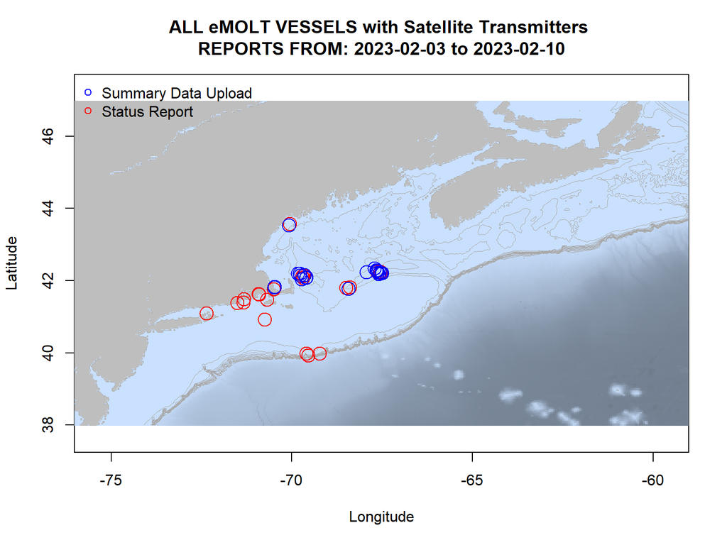

*Figure 3 - eMOLT Satellite Transmitter status plot for the previous week.* In the figure above, you can see the approximate locations where we received “Status Reports” (a ping from your system letting us know that it’s still working) and “Data Uploads” (actual temperature / depth data collected by your probes). The “Status Reports” come in every 12 hours or so when a system is powered up. “Data Uploads” only come in when you haul the probes. If you were out fishing and don’t see your approximate locations on here, please reach out because there may be a problem with your system.

### Announcements

We hope to see many of you at the upcoming Cooperative Research Summit in Providence this week. Rumor has it that some folks may adjourn to the Narragansett Brewery after the meeting, so maybe see you there as well.

On the topic of upcoming meetings, we are also looking forward to the Maine Fishermen’s Forum in a few weeks. The eMOLT program is cohosting a symposium with our colleagues from Commercial Fisheries Research Foundation and Ocean Data Networks. If you’re planning to attend the Forum, please stop by the symposium or the booth to meet George and provide your feedback and suggestions for the program. We love getting all of these oceanographic observations to feed to other scientists, but we want to make sure you’re getting what you need out of the program too. Also, if you have friends and colleagues who’d be interested in getting an eMOLT system on their boat, feel free to bring them by too! Erin’s been chatting with some folks about participating in our symposium, so thanks to Jim Barclay, Josh Miller, Jordan Drouin, and Dave Casoni for agreeing to provide your perspective.

Looking forward to seeing many of you soon!

All the best, George and JiM